# Data 607 Project-2

Alex Moyse

# The library Load in

```r
library(tidyverse)
library(openxlsx)
library(dplyr)
library(jsonlite)
library(httr)
library(lares)
```

# The Prelims

## Signing up for a NYT Developer account

## Testing it with postman

I really like Postman as a simple API tester, it really easily allows for parameterisation and testing of APIs, not to mention great logging and debugging.

Here is my first test of the NYT API

[figure not shown]

NYT API TEST

# A side note to keying

```r
test <- get_creds("service1")
key <- test$key
```

This is just a simple keying use for R

# JSON…Oh My!

As we can see from the test string above, we successfully get a reasonably well formed json response. It does a great job. From there, we can test the same string in R and attempt a basic read into a dataframe. First things first, lets handle keying

```r
Json_address = sprintf("https://api.nytimes.com/svc/movies/v2/reviews/search.json?query=%s&api-key=%s", "godfather", key)
json_raw <- fromJSON(Json_address)
json_table <- as.data.frame(json_raw,)
json_table
```

|  | status | copyright | has_more | num_results | results.display_title | results.mpaa_rating | results.critics_pick | results.byline | results.headline | results.summary_short | results.publication_date | results.opening_date | results.date_updated | results.link | results.multimedia |
| --- | --- | --- | --- | --- | --- | --- | --- | --- | --- | --- | --- | --- | --- | --- | --- |
| 1 | OK | Copyright (c) 2022 The New York Times Company. All Rights Reserved. | FALSE | 10 | The Black Godfather | TV-MA | 0 | BEN KENIGSBERG | ‘The Black Godfather’ Review: The Music Executive Who Made It All Happen | Reginald Hudlin’s documentary about Clarence Avant includes many golden anecdotes. | 2019-06-06 | 2019-06-07 | 2019-06-14 16:44:01 |  |  |
| 2 | OK | Copyright (c) 2022 The New York Times Company. All Rights Reserved. | FALSE | 10 | Square Grouper: The Godfathers of Ganja | R | 0 | RACHEL SALTZ | Adventures in the Drug Trades | “Square Grouper” is a documentary about pot smuggling in South Florida in the 1970s and ’80s. | 2011-04-14 | 2011-04-15 | 2017-11-02 04:18:13 |  |  |
| 3 | OK | Copyright (c) 2022 The New York Times Company. All Rights Reserved. | FALSE | 10 | Tokyo Godfathers | PG-13 | 1 | A. O. Scott | Three Down-and-Outs Rescue a Foundling From the Trash | Another marvel from Satoshi Kon, whose first two films, &quot;Perfect Blue&quot; and &quot;Millennium Actress,&quot; have already pushed Japanese feature-length animation toward greater realism and wi… | 2004-01-16 | NA | 2017-11-02 04:16:23 |  |  |
| 4 | OK | Copyright (c) 2022 The New York Times Company. All Rights Reserved. | FALSE | 10 | The Godfather, Part III | R | 1 | Janet Maslin | GODFATHER PART III (MOVIE) | Mafia heir trapped by legacy of past. Coppola's director's cut. Deeply moving. | 1990-12-25 | 1990-12-25 | 2017-11-02 04:17:42 |  |  |
| 5 | OK | Copyright (c) 2022 The New York Times Company. All Rights Reserved. | FALSE | 10 | The Godfather, Part II | R | 1 | VINCENT CANBY | Godfather: Part II, The (Movie) |  | 1974-12-13 | 1974-12-20 | 2017-11-02 04:17:27 |  |  |
| 6 | OK | Copyright (c) 2022 The New York Times Company. All Rights Reserved. | FALSE | 10 | The Black Godfather | R | 0 | NORA SAYRE | Black Godfather, The (Movie) |  | 1974-09-04 | NA | 2017-11-02 04:16:03 |  |  |
| 7 | OK | Copyright (c) 2022 The New York Times Company. All Rights Reserved. | FALSE | 10 | The Godfather | R | 1 | Vincent Canby | THE GODFATHER (MOVIE) | Puzo's Mafioso novel. Scalding and memorable. | 1972-03-16 | 1972-03-24 | 2017-11-02 04:17:26 |  |  |
| 8 | OK | Copyright (c) 2022 The New York Times Company. All Rights Reserved. | FALSE | 10 | Three Godfathers | Passed | 0 | BOSLEY CROWTHER | Three Godfathers | Outlaw trio and abandoned child. Typical, expert Ford western. | 1949-03-04 | 1948-12-01 | 2017-11-02 04:17:11 |  |  |
| 9 | OK | Copyright (c) 2022 The New York Times Company. All Rights Reserved. | FALSE | 10 | Miracle in the Sand | Passed | 0 | J.T.M. | Three Godfathers, The | Thieves reluctantly care for orphan. Tragic horse opera. | 1936-03-09 | 1936-03-06 | 2017-11-02 04:16:58 |  |  |
| 10 | OK | Copyright (c) 2022 The New York Times Company. All Rights Reserved. | FALSE | 10 | El Compadre Mendoza |  | 0 | Harry T. Smith | Compadre Mendoza, El | Landowner survives Mexican Revolution by supporting both sides. Directed by Fernando de Fuentes. | 1934-11-19 | 1934-11-18 | 2017-11-02 04:16:55 |  |  |

# Let’s Parameterize our request string

```r
search_term = "godfather"
url = sprintf("https://api.nytimes.com/svc/movies/v2/reviews/search.json?query=%s&api-key=%s", search_term, key)
```

# Let’s modularize our call

## Step 1-Let’s take our search term and key and make them variables, then try and pull the same table.

```r
search_term = "godfather"
api_url = sprintf("https://api.nytimes.com/svc/movies/v2/reviews/search.json?query=%s&api-key=%s", search_term, key)
json_raw <- fromJSON(api_url)
json_table <- as.data.frame(json_raw,)
json_table
```

|  | status | copyright | has_more | num_results | results.display_title | results.mpaa_rating | results.critics_pick | results.byline | results.headline | results.summary_short | results.publication_date | results.opening_date | results.date_updated | results.link | results.multimedia |
| --- | --- | --- | --- | --- | --- | --- | --- | --- | --- | --- | --- | --- | --- | --- | --- |
| 1 | OK | Copyright (c) 2022 The New York Times Company. All Rights Reserved. | FALSE | 10 | The Black Godfather | TV-MA | 0 | BEN KENIGSBERG | ‘The Black Godfather’ Review: The Music Executive Who Made It All Happen | Reginald Hudlin’s documentary about Clarence Avant includes many golden anecdotes. | 2019-06-06 | 2019-06-07 | 2019-06-14 16:44:01 |  |  |
| 2 | OK | Copyright (c) 2022 The New York Times Company. All Rights Reserved. | FALSE | 10 | Square Grouper: The Godfathers of Ganja | R | 0 | RACHEL SALTZ | Adventures in the Drug Trades | “Square Grouper” is a documentary about pot smuggling in South Florida in the 1970s and ’80s. | 2011-04-14 | 2011-04-15 | 2017-11-02 04:18:13 |  |  |
| 3 | OK | Copyright (c) 2022 The New York Times Company. All Rights Reserved. | FALSE | 10 | Tokyo Godfathers | PG-13 | 1 | A. O. Scott | Three Down-and-Outs Rescue a Foundling From the Trash | Another marvel from Satoshi Kon, whose first two films, &quot;Perfect Blue&quot; and &quot;Millennium Actress,&quot; have already pushed Japanese feature-length animation toward greater realism and wi… | 2004-01-16 | NA | 2017-11-02 04:16:23 |  |  |
| 4 | OK | Copyright (c) 2022 The New York Times Company. All Rights Reserved. | FALSE | 10 | The Godfather, Part III | R | 1 | Janet Maslin | GODFATHER PART III (MOVIE) | Mafia heir trapped by legacy of past. Coppola's director's cut. Deeply moving. | 1990-12-25 | 1990-12-25 | 2017-11-02 04:17:42 |  |  |
| 5 | OK | Copyright (c) 2022 The New York Times Company. All Rights Reserved. | FALSE | 10 | The Godfather, Part II | R | 1 | VINCENT CANBY | Godfather: Part II, The (Movie) |  | 1974-12-13 | 1974-12-20 | 2017-11-02 04:17:27 |  |  |
| 6 | OK | Copyright (c) 2022 The New York Times Company. All Rights Reserved. | FALSE | 10 | The Black Godfather | R | 0 | NORA SAYRE | Black Godfather, The (Movie) |  | 1974-09-04 | NA | 2017-11-02 04:16:03 |  |  |
| 7 | OK | Copyright (c) 2022 The New York Times Company. All Rights Reserved. | FALSE | 10 | The Godfather | R | 1 | Vincent Canby | THE GODFATHER (MOVIE) | Puzo's Mafioso novel. Scalding and memorable. | 1972-03-16 | 1972-03-24 | 2017-11-02 04:17:26 |  |  |
| 8 | OK | Copyright (c) 2022 The New York Times Company. All Rights Reserved. | FALSE | 10 | Three Godfathers | Passed | 0 | BOSLEY CROWTHER | Three Godfathers | Outlaw trio and abandoned child. Typical, expert Ford western. | 1949-03-04 | 1948-12-01 | 2017-11-02 04:17:11 |  |  |
| 9 | OK | Copyright (c) 2022 The New York Times Company. All Rights Reserved. | FALSE | 10 | Miracle in the Sand | Passed | 0 | J.T.M. | Three Godfathers, The | Thieves reluctantly care for orphan. Tragic horse opera. | 1936-03-09 | 1936-03-06 | 2017-11-02 04:16:58 |  |  |
| 10 | OK | Copyright (c) 2022 The New York Times Company. All Rights Reserved. | FALSE | 10 | El Compadre Mendoza |  | 0 | Harry T. Smith | Compadre Mendoza, El | Landowner survives Mexican Revolution by supporting both sides. Directed by Fernando de Fuentes. | 1934-11-19 | 1934-11-18 | 2017-11-02 04:16:55 |  |  |

## Step 2-Making a function

```r
search_term = "godfather"
getNytData <- function(search_term, key) {
api_url = sprintf("https://api.nytimes.com/svc/movies/v2/reviews/search.json?query=%s&api-key=%s", search_term, key)
api_url
json_raw <- fromJSON(api_url)
json_table <- as.data.frame(json_raw,)
return(json_table)
}
getNytData(search_term, key)
```

|  | status | copyright | has_more | num_results | results.display_title | results.mpaa_rating | results.critics_pick | results.byline | results.headline | results.summary_short | results.publication_date | results.opening_date | results.date_updated | results.link | results.multimedia |
| --- | --- | --- | --- | --- | --- | --- | --- | --- | --- | --- | --- | --- | --- | --- | --- |
| 1 | OK | Copyright (c) 2022 The New York Times Company. All Rights Reserved. | FALSE | 10 | The Black Godfather | TV-MA | 0 | BEN KENIGSBERG | ‘The Black Godfather’ Review: The Music Executive Who Made It All Happen | Reginald Hudlin’s documentary about Clarence Avant includes many golden anecdotes. | 2019-06-06 | 2019-06-07 | 2019-06-14 16:44:01 |  |  |
| 2 | OK | Copyright (c) 2022 The New York Times Company. All Rights Reserved. | FALSE | 10 | Square Grouper: The Godfathers of Ganja | R | 0 | RACHEL SALTZ | Adventures in the Drug Trades | “Square Grouper” is a documentary about pot smuggling in South Florida in the 1970s and ’80s. | 2011-04-14 | 2011-04-15 | 2017-11-02 04:18:13 |  |  |
| 3 | OK | Copyright (c) 2022 The New York Times Company. All Rights Reserved. | FALSE | 10 | Tokyo Godfathers | PG-13 | 1 | A. O. Scott | Three Down-and-Outs Rescue a Foundling From the Trash | Another marvel from Satoshi Kon, whose first two films, &quot;Perfect Blue&quot; and &quot;Millennium Actress,&quot; have already pushed Japanese feature-length animation toward greater realism and wi… | 2004-01-16 | NA | 2017-11-02 04:16:23 |  |  |
| 4 | OK | Copyright (c) 2022 The New York Times Company. All Rights Reserved. | FALSE | 10 | The Godfather, Part III | R | 1 | Janet Maslin | GODFATHER PART III (MOVIE) | Mafia heir trapped by legacy of past. Coppola's director's cut. Deeply moving. | 1990-12-25 | 1990-12-25 | 2017-11-02 04:17:42 |  |  |
| 5 | OK | Copyright (c) 2022 The New York Times Company. All Rights Reserved. | FALSE | 10 | The Godfather, Part II | R | 1 | VINCENT CANBY | Godfather: Part II, The (Movie) |  | 1974-12-13 | 1974-12-20 | 2017-11-02 04:17:27 |  |  |
| 6 | OK | Copyright (c) 2022 The New York Times Company. All Rights Reserved. | FALSE | 10 | The Black Godfather | R | 0 | NORA SAYRE | Black Godfather, The (Movie) |  | 1974-09-04 | NA | 2017-11-02 04:16:03 |  |  |
| 7 | OK | Copyright (c) 2022 The New York Times Company. All Rights Reserved. | FALSE | 10 | The Godfather | R | 1 | Vincent Canby | THE GODFATHER (MOVIE) | Puzo's Mafioso novel. Scalding and memorable. | 1972-03-16 | 1972-03-24 | 2017-11-02 04:17:26 |  |  |
| 8 | OK | Copyright (c) 2022 The New York Times Company. All Rights Reserved. | FALSE | 10 | Three Godfathers | Passed | 0 | BOSLEY CROWTHER | Three Godfathers | Outlaw trio and abandoned child. Typical, expert Ford western. | 1949-03-04 | 1948-12-01 | 2017-11-02 04:17:11 |  |  |
| 9 | OK | Copyright (c) 2022 The New York Times Company. All Rights Reserved. | FALSE | 10 | Miracle in the Sand | Passed | 0 | J.T.M. | Three Godfathers, The | Thieves reluctantly care for orphan. Tragic horse opera. | 1936-03-09 | 1936-03-06 | 2017-11-02 04:16:58 |  |  |
| 10 | OK | Copyright (c) 2022 The New York Times Company. All Rights Reserved. | FALSE | 10 | El Compadre Mendoza |  | 0 | Harry T. Smith | Compadre Mendoza, El | Landowner survives Mexican Revolution by supporting both sides. Directed by Fernando de Fuentes. | 1934-11-19 | 1934-11-18 | 2017-11-02 04:16:55 |  |  |

## The Function works!

So at this point, we have a function that works, a key, and best of all its all secure! At this point we are complete but there are still a few things I want to try!

# The things to play with

1. can you import an image from a link in R Studio:

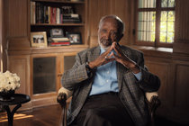

YES!

2. How I would make this better Ideally I’d love to spin up a container, keep the secret as an env, and then launch it in that container, but this project doesn’t require that degree of complexity!

# Conclusion

This project is finished as I connected to an API & loaded it into a dataframe!